# Recapture rates and habitat associations of White-faced Darter *Leucorhinnia dubia* on Fenn’s and Whixall Moss, Shropshire, UK

Rachel Davies, Achaz von Hardenberg & Matthew Geary Conservation Biology Research Group, Department of Biological Sciences, University of Chester, Parkgate Road, CH1 4BJ Chester, UK

## Introduction

A bias exists in conservation research towards charismatic vertebrates (Di Marco et al. 2017). Although Odonata are charismatic invertebrates they are not immune to this bias (Clausnitzer et al. 2009). In addition much research into Odonata focuses on physiology, evolution and behaviour (Córdoba-Aguilar 2008) and they have rarely been the focus of conservation research (Clausnitzer et al. 2009). Basic ecological research into demography, survival and habitat use is essential for effective protection of species and habitats. For any taxa this requires detailed ecological and life history data collected in the field. These are often difficult to obtain, particularly on large scales. Integrating large scale data such as presence-only distribution datasets with more detailed local information is a current challenge in conservation ecology (Powney and Isaac 2015).

Methods to analyse habitat preferences are varied depending on the data available. The current ‘gold standard’ is the use of site occupancy models which take into account detectability (i.e. the probability that a species is detected in a site if present) when estimating occupancy: the probability that a species is present in a site (MacKenzie et al. 2003). Models using this framework help us to avoid the age-old problem of “imperfect detection”, i.e. failing to spot a species during a survey on a site where it is actually present (MacKenzie et al. 2003). However, these models require repeated surveys where both detections and non-detections are recorded; these data are not always available, especially in the case of historic data collected by volunteers. On larger scales a number of methods exist which can use only presence records along with environmental covariates (Elith and Leathwick 2009). These can tell us about habitat use but are constrained to estimate a measure of the relative importance of habitats rather than the true probability of presence (Elith et al. 2011) and are limited by the environmental data available. At very small scales, such as individual protected areas, detailed data on habitats and landcover can be difficult to obtain. Datasets such as the UK lancover map (LCM2015), although the resolution is 15m, are too crude for local studies in some areas. Simpler methods which indicate preferred habitat, such as selection indices (Manly et al. 2007), have fewer assumptions and can be revealing even at small scales (Neu, Byers, and Peek 1974).

Investigating survival and movement requires individual recognition and methods using a capture mark-recapture approach are well established (McCrea and Morgan 2014). Such analyses can tell us about the age-sex specific survival probabilites of individuals, the use of different sites or habitats and how these change over time and the likelihood of encountering individuals again in the future. High quality data of this type can provide accurate estimates of population size. Mark-recapture methods have been used on Odonata populations in the past to monitor rare species (Foster and Soluk 2004; Cordero-Rivera and Stoks 2008) as well as to study the life history of more abundant species (Anholt, Vorburger, and Knaus 2001). Odonata, because of the ease by which they can usually be individually marked, have also been used as model species for methodological research on the development of mark-recapture techniques (Manly, B.F.J. and Parr, M.J. 1968).

The White-faced Darter (*Leucorrhinia dubia*), is a specialist of lowland peatbogs where it breeds in bog pools containing sphagnum mosses (Dave Smallshire and Swash 2004). It has a life cycle that includes a 1-3-year larval period, followed by an adult flight period (Dave Smallshire and Swash 2004). Emergence is weather dependent and will typically start in either May or June each year. Tenerals are thought to disperse to low scrub following emergence, staying there whilst they mature. Following this, the adults return to breeding pools, with males returning sooner than females so they can hold breeding territories (Dave Smallshire and Swash 2004). The adult flight period typically ends in either late July or August. The White-faced Darter has a scattered distribution and its populations have been declining in Britain over the past several decades. Despite being classified as a species of least concern on the IUCN Red Data List (Clausnitzer et al. 2009), this decline in Britain has resulted in a classification of Endangered on the Odonata Red Data List for Britain (T. Beynon et al. 2008). This decline is largely attributed to habitat loss and the resulting habitat fragmentation (T. Beynon et al. 2008); as over 90% of England’s peatbogs have been lost or substantially damaged to date (Nature 2002). There are currently only three stable historical populations of White-faced Darter in England, along with two recently reintroduced populations, one in Cumbria and one in Cheshire (Clarke 2014; Meredith 2017).

Here we use two methods to investigate important ecological characteristics of White-faced Darter on Fenn’s and Whixall moss in Shropshire, UK. We use mark-recapture methods to investigate survival and movements of adults during the flight period and a selection index method to investigate habitat use. These methods can both contribute to our understanding of the spatial use of habitat by White-faced Darter and can help us to prioritise future research for this species.

## Methods

### Study area

Fenn’s, Whixall and Bettisfield Mosses (FWB Mosses) are located within Shropshire (52°55′N 2°46′W) and they support a large, long-established population of White-faced Darter. FWB Mosses are a lowland raised bog complex, stretching nearly 1000 hectares (Meredith 2017). Historically, the mosses were used for peat cutting and in the 19<sub>th</sub> century they were drained to allow larger-scale operations to take place (Meredith 2017). Eventually, in 1990, the mosses were taken over by English Nature (now Natural England) and long-term restoration began, benefitting a whole host of mossland species, including the White-faced Darter. (Meredith 2017).

### Field methods

The site was surveyed twice per week between the 22nd of May and 6th of July 2017. This encompassed the peak flight period of White-faced Darter (Dave Smallshire and Swash 2004). Two separate breeding pools within FWB Mosses were sampled simultaneously, along with a variety of scrub and other potentially suitable habitat. On each sampling occasion, the full sampling area was searched for any White-faced Darter individuals. Different routes were walked on each occasion to allow different areas within the sampling area to be searched at different times of the day. Sampling sessions lasting between 5-10 hours, being carried out between 10am and 4pm, as this is the favoured flight period for adult dragonflies (D. Smallshire and Beynon 2010). Sampling days were weather dependent (Chin and Taylor 2009) and weather conditions were recorded on all sampling days.

*Selection index* White-faced Darter presence was recorded while searching the site during the capture-mark-recapture study. This included captured individuals as well as those seen on survey routes but not captured. On each occasion the location of the individual was recorded with a hand-held GPS unit (Garmin GPSMAP 64). Additionally, a phase 1 habitat survey (Committee 2010) was conducted across the study site to produce a habitat map using 100 x 100 m grid cells. The proportion of five habitat types were recorded in each square: moss (peat moss, rushes and sedges), scrub (low woody vegetation), scrub-moss (peat moss with low woody vegetation), water (open pools) and woodland (mature trees). From this the dominat habitat in each square was calculated. Of these, only water was not used in analyses as adult individuals tended to be sighted over terrestrial habitat.

### Data analysis

*Capture-mark-recapture*  
A single-season Cormack-Jolly-Seber model (Pradel 1996) was used to determine to probability of survival between sampling days and the probability of recapture on sampling days for the capture-mark-recapture data. Capture-mark-recapture analysis was carried out using the ‘RMark’ package version 2.2.2 (Fouchet et al. 2015), in R version 3.5.0 (R Core Team 2018).

## Results

*Capture-Mark-Recapture Model*

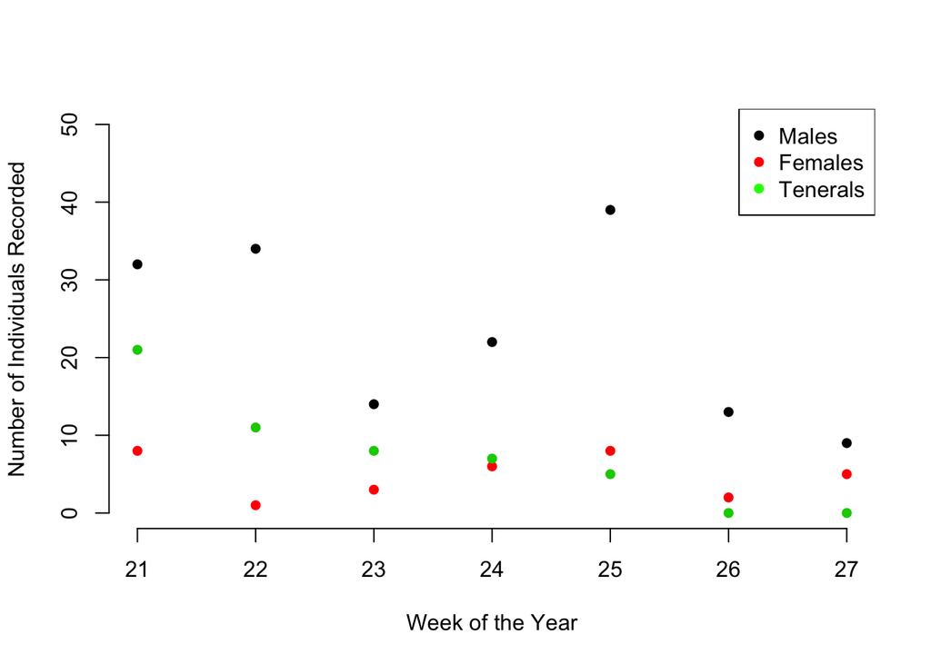

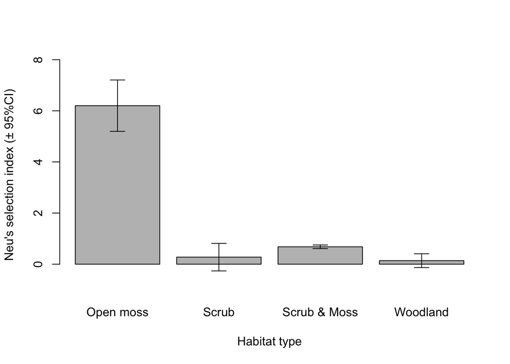

### Discussion

Data which allows the estimation of detectability can easily be collected with just a few minor changes to currently common survey methods. In fact, the majority of these suggestions are already being requested by the BDS to provide data for the upcoming State of the Nation’s Dragonflies in 2020. We would like to add our voice to these calls to record complete lists and to repeat site visits. Complete lists are records of all the Odonata species detected on a single visit and allow non-detection to be inferred where species are not recorded (N. J. Isaac and Pocock 2015). This requires recorders to note very common species as well as rarities. Unfortunatley, there is a tendency in biological recordings to note only the rare or exciting species (e.g. first record of the year) and this can bias our inferences about population change amongst more common species (N. J. Isaac et al. 2014). Repeated site visits allow us to estimate the detectability of a species (MacKenzie et al. 2003) and consequently get unbiased estimates of occupancy, not affected by imperfect detection. We would also like to suggest that where possible recorders include some measure of effort in their surveys (e.g. time spent surveying or distance walked). Ideally this would be standardized and included in official protocols such as those already commonly in use for bird surveys.

We present the results in this paper as an indication of what can be done in terms of conservation research in Odonata. Although we have been unable to make firm inferences regarding White-faced Darter survival and habitat preference at this stage this study can provide valuable information which can contribute to the design of future studies. We suggest that research into the conservation ecology of White-faced Darter along with other Odonata species threatened with declining ranges, declining populations or habitat loss is essential to the long-term conservation of these species. Methods for such studies can be well informed by current practices used with other taxa. In particular, the analytical advances made in ornithology, research on Lepidoptera and work related to the use of data collected through citizen science provide a fantastic opportunity to advance our knowledge on the conservation ecology of Odonata.

### Acknowledgements

We would like to express our thanks to the British Dragonfly Society who supported this work financially, Natural England who provided permission to access the field site and to Chris Meredith who provided invaluable help in the field and with advice on White-faced Darter ecology and behaviour. We would also like to thank all of the volunteers who helped with fieldwork in the summer of 2017.

### References

Allen, Katherine A., and David J. Thompson. 2014. “Population Size and Survival Estimates for the Rare Damselflies, Coenagrion Mercuriale and Ischnura Pumilio.” *Insect Conservation and Diversity* 7 (3): 241–51.

Anholt, Bradley R., Christoph Vorburger, and Peter Knaus. 2001. “Mark-Recapture Estimates of Daily Survival Rates of Two Damselflies (Coenagrion Puella and Ischnura Elegans).” *Canadian Journal of Zoology* 79 (5): 895–99.

Beynon, Tim, Steve Cham, Ian Johnson, Ruary Mackenzie Dodds, Peter Mill, Norman Moore, Charlotte Murray, Adrian Parr, Bridget Peacock, and Val Perrin. 2008. “The Odonata Red Data List for Great Britain.”

Boudot, Jean-Pierre, and Vincent J. Kalkman. 2015. *Atlas of the European Dragonflies and Damselflies*. KNNV Publishing.

Cham, Stephen A, Brian Nelson, Adrian Parr, Steven Prentice, Dave Smallshire, and Pam Taylor. 2014. *Atlas of Dragonflies in Britain and Ireland*. Field Studies Council.

Chin, Krista S., and Philip D. Taylor. 2009. “Interactive Effects of Distance and Matrix on the Movements of a Peatland Dragonfly.” *Ecography* 32 (5): 715–22.

Clarke, D. 2014. “The White-Faced Darter (Leucorrhina Dubia Vander Linden) Re-Introduction Project in Cumbria.” *Journal of the British Dragonfly Society* 30: 54–78.

Clausnitzer, Viola, Vincent J. Kalkman, Mala Ram, Ben Collen, Jonathan E.M. Baillie, Matjaž Bedjanič, William R.T. Darwall, et al. 2009. “Odonata Enter the Biodiversity Crisis Debate: The First Global Assessment of an Insect Group.” *Biological Conservation* 142 (8): 1864–9. doi:10.1016/j.biocon.2009.03.028.

Committee, Joint Nature Conservation. 2010. “Handbook for Phase 1 Habitat Survey-a Technique for Environmental Audit.” *JNCC, Peterborough*.

Cordero-Rivera, Adolfo, and Robby Stoks. 2008. “Mark-Recapture Studies and Demography.” In *Dragonflies and Damselflies: Model Organisms for Ecological and Evolutionary Research*, 7–20. Ocford, UK: OUP Oxford.

Córdoba-Aguilar, Alex. 2008. *Dragonflies and Damselflies: Model Organisms for Ecological and Evolutionary Research*. Oxford, UK: OUP Oxford.

Di Marco, Moreno, Sarah Chapman, Glenn Althor, Stephen Kearney, Charles Besancon, Nathalie Butt, Joseph M. Maina, et al. 2017. “Changing Trends and Persisting Biases in Three Decades of Conservation Science.” *Global Ecology and Conservation* 10 (April): 32–42. doi:10.1016/j.gecco.2017.01.008.

Dolný, Aleš, Hana Šigutová, Stanislav Ožana, and Lukáš Choleva. 2018. “How Difficult Is It to Reintroduce a Dragonfly? Fifteen Years Monitoring Leucorrhinia Dubia at the Receiving Site.” *Biological Conservation* 218 (February): 110–17. doi:10.1016/j.biocon.2017.12.011.

Elith, Jane, and John R. Leathwick. 2009. “Species Distribution Models: Ecological Explanation and Prediction Across Space and Time.” *Annual Review of Ecology, Evolution, and Systematics* 40: 677–97.

Elith, Jane, Steven J. Phillips, Trevor Hastie, Miroslav Dudík, Yung En Chee, and Colin J. Yates. 2011. “A Statistical Explanation of MaxEnt for Ecologists.” *Diversity and Distributions* 17 (1): 43–57.

Foley, Jonathan A., Ruth DeFries, Gregory P. Asner, Carol Barford, Gordon Bonan, Stephen R. Carpenter, F. Stuart Chapin, et al. 2005. “Global Consequences of Land Use.” *Science* 309 (5734): 570–74. doi:10.1126/science.1111772.

Foster, S. E., and D. A. Soluk. 2004. “Evaluating Exuvia Collection as a Management Tool for the Federally Endangered Hine’s Emerald Dragonfly, Somatochlora Hineana Williamson (Odonata: Cordulidae).” *Biological Conservation* 118 (1): 15–20.

Fouchet, David, Hugues Santin‐Janin, Frank Sauvage, Nigel Gilles Yoccoz, and Dominique Pontier. 2015. “An R Package for Analysing Survival Using Continuous-Time Open Capture–recapture Models.” *Methods in Ecology and Evolution* 7 (5): 518–28. doi:10.1111/2041-210X.12497.

Holloway, G. J., G. H. Griffiths, and P. Richardson. 2003. “Conservation Strategy Maps: A Tool to Facilitate Biodiversity Action Planning Illustrated Using the Heath Fritillary Butterfly.” *Journal of Applied Ecology* 40 (2): 413–21. doi:10.1046/j.1365-2664.2003.00788.x.

Isaac, Nick JB, and Michael JO Pocock. 2015. “Bias and Information in Biological Records.” *Biological Journal of the Linnean Society* 115 (3): 522–31.

Isaac, Nick JB, Arco J. Strien, Tom A. August, Marnix P. Zeeuw, and David B. Roy. 2014. “Statistics for Citizen Science: Extracting Signals of Change from Noisy Ecological Data.” *Methods in Ecology and Evolution* 5 (10): 1052–60.

Lettink, Marieke, and Doug P. Armstrong. 2003. “An Introduction to Using Mark-Recapture Analysis for Monitoring Threatened Species.” *Department of Conservation Technical Series A* 28: 5–32.

MacKenzie, Darryl I., James D. Nichols, James E. Hines, Melinda G. Knutson, and Alan B. Franklin. 2003. “Estimating Site Occupancy, Colonization, and Local Extinction When a Species Is Detected Imperfectly.” *Ecology* 84 (8): 2200–2207.

Manly, B. F. L., Lyman McDonald, Dana L. Thomas, Trent L. McDonald, and Wallace P. Erickson. 2007. *Resource Selection by Animals: Statistical Design and Analysis for Field Studies*. Springer Science & Business Media.

Manly, B.F.J., and Parr, M.J. 1968. “A New Method for Estimating Population Size, Survivorship, and Birth Rate from Capture-Recapture Data.” *Transactions of the Royal Society for British Entomology* 18: 81–89.

Mazerolle, Marc J., Larissa L. Bailey, William L. Kendall, J. Andrew Royle, Sarah J. Converse, and James D. Nichols. 2007. “Making Great Leaps Forward: Accounting for Detectability in Herpetological Field Studies.” *Journal of Herpetology* 41 (4): 672–89.

McCrea, Rachel S., and Byron JT Morgan. 2014. *Analysis of Capture-Recapture Data*. CRC Press.

Meredith, Chris. 2017. “Reintroduction of Leucorrhinia Dubia (Vander Linden) (White-Faced Darter) to Delamere Forest, Cheshire.” *Journal of the British Dragonfly Society* 33 (1): 50–72.

Merritt, Robert, Norman Winfrid Moore, and Brian C Eversham. 1996. *Atlas of the Dragonflies of Britain and Ireland*. HMSO.

Nature, English. 2002. “Peat Bog Conservation: The Importance of Lowland Raised Bogs.” *Peterborough, UK*.

Neu, Clyde W., C. Randall Byers, and James M. Peek. 1974. “A Technique for Analysis of Utilization-Availability Data.” *The Journal of Wildlife Management*, 541–45.

Powney, Gary D., and Nick J. B. Isaac. 2015. “Beyond Maps: A Review of the Applications of Biological Records.” *Biological Journal of the Linnean Society* 115 (3): 532–42. doi:10.1111/bij.12517.

Pradel, Roger. 1996. “Utilization of Capture-Mark-Recapture for the Study of Recruitment and Population Growth Rate.” *Biometrics*, 703–9.

R Core Team. 2018. “R: A Language and Environment for Statistical Computing.” Vienna, Austria: R Foundation for Statistical Computing. https://www.R-project.org/.

Sala, O. E. 2000. “Global Biodiversity Scenarios for the Year 2100.” *Science* 287 (5459): 1770–4. doi:10.1126/science.287.5459.1770.

Smallshire, D., and T. Beynon. 2010. “Dragonfly Monitoring Scheme Manual.” *British Dragonfly Society,< Http://Www. British-Dragonflies. Org. Uk/Sites/British-Dragonflies. Org. Uk/Files/Images/Dragonfly% 20Monitoring% 20Scheme* 202010.

Smallshire, Dave, and A. Swash. 2004. *Britain’s Dragonflies*. Old Basing Wild Guides Ltd.